# Analysis of Kickstarter Online Fundraising Platform

# Python Programming MGMT-586 Project

## Session 1: Group 8

Anil Cavale  
Angelina Joseph  
Eshan Sharma  
Mansha Kalra  
Sriya Musunuru

# Introduction and Rationale:

Crowdfunding platforms are the lifeblood of ideas and projects that need a pedestal to get funds and grow. Kickstarter is one such platform that focuses on celebrating creative projects and raise a target amount to be pledged within a stipulated timeframe.

This project is directed at analyzing Kickstarter from two perspectives – Internally, to understand campaign performance and externally, from a start-up creator's perspective, to understand whether Kickstarter would be the right choice for promoting their idea.

The dataset chosen contains Campaign level details including the final outcome - success or failure and is hosted publicly on Kaggle https://www.kaggle.com/kemical/kickstarter-projects?select=ks-projects-201801.csv.

# Setting up environment

```python
# Importing libraries for analysis
import pandas as pd
import numpy as np
import datetime as dt
import matplotlib.pyplot as plt
import seaborn as sns
%matplotlib inline
from wordcloud import WordCloud, STOPWORDS, ImageColorGenerator
```

```python
import pygal # Module for creating worldmap
from pygal.style import SaturateStyle
from IPython.display import SVG
```

```python
from sklearn.preprocessing import MinMaxScaler
from sklearn.model_selection import train_test_split
from sklearn.tree import DecisionTreeClassifier
from sklearn.metrics import classification_report
```

```python
pd.set_option('display.float_format', lambda x: '%.3f' % x)
```

```python
# Styles: white, dark, whitegrid, darkgrid, ticks
sns.set_style("whitegrid")
sns.set_context("notebook")
```

# Reading the Data

```python
data = pd.read_csv('ks-projects-201801.csv')
```

## Basic Checks

The dataset has 378661 records with 15 columns before cleaning and preprocessing.

```python
data.info()
```

```
<class 'pandas.core.frame.DataFrame'>
RangeIndex: 378661 entries, 0 to 378660
Data columns (total 15 columns):
 #   Column            Non-Null Count   Dtype
---  ------            --------------   -----
 0   ID                378661 non-null  int64
 1   name              378657 non-null  object
 2   category          378661 non-null  object
 3   main_category     378661 non-null  object
 4   currency          378661 non-null  object
 5   deadline          378661 non-null  object
 6   goal              378661 non-null  float64
 7   launched          378661 non-null  object
 8   pledged           378661 non-null  float64
 9   state             378661 non-null  object
 10  backers           378661 non-null  int64
 11  country           378661 non-null  object
 12  usd pledged       374864 non-null  float64
 13  usd_pledged_real  378661 non-null  float64
 14  usd_goal_real     378661 non-null  float64
dtypes: float64(5), int64(2), object(8)
memory usage: 43.3+ MB
```

```python
data.describe()
```

|  | ID | goal | pledged | backers | usd pledged | usd_pledged_real | usd_goal_real |
| --- | --- | --- | --- | --- | --- | --- | --- |
| count | 378661.000 | 378661.000 | 378661.000 | 378661.000 | 374864.000 | 378661.000 | 378661.000 |
| mean | 1074731191.989 | 49080.792 | 9682.979 | 105.617 | 7036.729 | 9058.924 | 45454.401 |
| std | 619086204.323 | 1183391.259 | 95636.010 | 907.185 | 78639.745 | 90973.343 | 1152950.055 |
| min | 5971.000 | 0.010 | 0.000 | 0.000 | 0.000 | 0.000 | 0.010 |
| 25% | 538263516.000 | 2000.000 | 30.000 | 2.000 | 16.980 | 31.000 | 2000.000 |
| 50% | 1075275634.000 | 5200.000 | 620.000 | 12.000 | 394.720 | 624.330 | 5500.000 |
| 75% | 1610148624.000 | 16000.000 | 4076.000 | 56.000 | 3034.090 | 4050.000 | 15500.000 |
| max | 2147476221.000 | 100000000.000 | 20338986.270 | 219382.000 | 20338986.270 | 20338986.270 | 166361390.710 |

```python
data.describe(include=np.object)
```

|  | name | category | main_category | currency | deadline | launched | state | country |
| --- | --- | --- | --- | --- | --- | --- | --- | --- |
| count | 378657 | 378661 | 378661 | 378661 | 378661 | 378661 | 378661 | 378661 |
| unique | 375764 | 159 | 15 | 14 | 3164 | 378089 | 6 | 23 |
| top | New EP/Music Development | Product Design | Film & Video | USD | 2014-08-08 | 1970-01-01 01:00:00 | failed | US |
| freq | 41 | 22314 | 63585 | 295365 | 705 | 7 | 197719 | 292627 |

```python
data.isnull().sum()
```

```
ID                     0
name                   4
category               0
main_category          0
currency               0
deadline               0
goal                   0
launched               0
pledged                0
state                  0
backers                0
country                0
usd pledged         3797
usd_pledged_real       0
usd_goal_real          0
dtype: int64
```

A very small % of Nulls are present in usd_pledged and name.

```python
data["name"].isnull().value_counts(normalize=True)
```

```
False   1.000
True    0.000
Name: name, dtype: float64
```

```python
data['usd pledged'].isnull().value_counts(normalize=True)
```

```
False   0.990
True    0.010
Name: usd pledged, dtype: float64
```

# Data cleaning and Preprocessing

The columns USD Pledged, Goal and Pledged will not be used for the analysis as there are alternate columns titled usd_pledged_real and usd_goal_real. These columns are made available in the original dataset through conversion from an external API for foreign exchange conversion.

```python
# Creating a copy of the original dataset for cleaning
data_clean=data.copy()
```

```python
#dropping unnecessary columns
data_clean.drop(columns=['usd pledged','goal','pledged'],axis=1,inplace=True)
```

```python
#dropping 4 rows whose "name" value was NaN
data_clean.dropna(subset=['name'],inplace=True)
```

```python
#removing those rows whose "country" value was 'N,0"'
mask=data_clean['country']!='N,0"'
data_clean=data_clean[mask]
```

```python
#taking out those rows whose "state" value was either "successful" or "failed"
mask1=data_clean['state']=='successful'
mask2=data_clean['state']=='failed'
data_clean=data_clean[mask1 | mask2]
```

```python
#removing those rows where backers=0 but usd_pledged_real>0
mask1=data_clean['backers']==0
mask2=data_clean['usd_pledged_real']>0
data_clean=data_clean[~(mask1 & mask2)]
```

```python
#removing those rows where usd_pledged_real>=usd_goal_real but state=failed
mask1=data_clean['usd_pledged_real']>=data_clean['usd_goal_real']
mask2=data_clean['state']=='failed'
data_clean=data_clean[~(mask1 & mask2)]
```

```python
#removing those rows where usd_pledged_real<usd_goal_real but state=successful
mask1=data_clean['usd_pledged_real']<data_clean['usd_goal_real']
mask2=data_clean['state']=='successful'
data_clean=data_clean[~(mask1 & mask2)]
```

```python
#separating year from the 'launched' date
data_clean['year']=pd.to_datetime(data_clean['launched']).dt.year
```

```python
#removing those row where year=1970 since it's an input error
mask=data_clean['year']!=1970
data_clean=data_clean[mask]
```

```python
# Converting ID to object type
data_clean['ID']=data_clean['ID'].astype('object')
```

```python
data_clean.isnull().sum()
```

```
ID                  0
name                0
category            0
main_category       0
currency            0
deadline            0
launched            0
state               0
backers             0
country             0
usd_pledged_real    0
usd_goal_real       0
year                0
dtype: int64
```

```python
data_clean.info()
```

```
<class 'pandas.core.frame.DataFrame'>
Int64Index: 331448 entries, 0 to 378660
Data columns (total 13 columns):
 #   Column            Non-Null Count   Dtype
---  ------            --------------   -----
 0   ID                331448 non-null  object
 1   name              331448 non-null  object
 2   category          331448 non-null  object
 3   main_category     331448 non-null  object
 4   currency          331448 non-null  object
 5   deadline          331448 non-null  object
 6   launched          331448 non-null  object
 7   state             331448 non-null  object
 8   backers           331448 non-null  int64
 9   country           331448 non-null  object
 10  usd_pledged_real  331448 non-null  float64
 11  usd_goal_real     331448 non-null  float64
 12  year              331448 non-null  int64
dtypes: float64(2), int64(2), object(9)
memory usage: 35.4+ MB
```

# Feature Engineering

Creating additional variables useful for analysis.

```python
#calculating duration of the project on kickstarter website
data_clean['launched']=pd.to_datetime(data_clean['launched']).dt.date
data_clean['deadline']=pd.to_datetime(data_clean['deadline']).dt.date
data_clean['duration']=data_clean['deadline']-data_clean['launched']
data_clean['duration']=data_clean['duration'].dt.days
```

```python
#caluclating the difference between usd_goal_real and usd_pledged_real
data_clean['difference']=data_clean['usd_goal_real']-data_clean['usd_pledged_real']
```

```python
# Dividing goal amount into categorical bins for ease of understanding
# Creating labels for goal amount bins
labels = ['Zero - 100', '100 - 1K', '1K - 5K','5K - 50K','50K - 100K','100K - 500K','500K - 1M','1M - 5M','5M+']

bins=[0,100,1000,5000,50000,100000,500000,1000000,5000000,20000000] # the lower bin value is included in pd.cut
data_clean['project_scale']=pd.cut(data_clean['usd_goal_real'],bins=bins,labels=labels)
```

```python
# Creating binary flag for succesful projects used for calculating success rate
data_clean['success']=np.where(data_clean['state']== 'successful', 1, 0)
```

```python
#separating month from the 'launched' date
data_clean['month']=pd.to_datetime(data_clean['launched']).dt.month
```

```python
# Converting month and year to object type
data_clean['month']=data_clean['month'].astype('object')
data_clean['year']=data_clean['year'].astype('object')
```

```python
data_clean.head()
```

|  | ID | name | category | main_category | currency | deadline | launched | state | backers | country | usd_pledged_real | usd_goal_real | year | duration | difference | project_scale | success | month |
| --- | --- | --- | --- | --- | --- | --- | --- | --- | --- | --- | --- | --- | --- | --- | --- | --- | --- | --- |
| 0 | 1000002330 | The Songs of Adelaide & Abullah | Poetry | Publishing | GBP | 2015-10-09 | 2015-08-11 | failed | 0 | GB | 0.000 | 1533.950 | 2015 | 59 | 1533.950 | 1K - 5K | 0 | 8 |
| 1 | 1000003930 | Greeting From Earth: ZGAC Arts Capsule For ET | Narrative Film | Film & Video | USD | 2017-11-01 | 2017-09-02 | failed | 15 | US | 2421.000 | 30000.000 | 2017 | 60 | 27579.000 | 5K - 50K | 0 | 9 |
| 2 | 1000004038 | Where is Hank? | Narrative Film | Film & Video | USD | 2013-02-26 | 2013-01-12 | failed | 3 | US | 220.000 | 45000.000 | 2013 | 45 | 44780.000 | 5K - 50K | 0 | 1 |
| 3 | 1000007540 | ToshiCapital Rekordz Needs Help to Complete Album | Music | Music | USD | 2012-04-16 | 2012-03-17 | failed | 1 | US | 1.000 | 5000.000 | 2012 | 30 | 4999.000 | 1K - 5K | 0 | 3 |
| 5 | 1000014025 | Monarch Espresso Bar | Restaurants | Food | USD | 2016-04-01 | 2016-02-26 | successful | 224 | US | 52375.000 | 50000.000 | 2016 | 35 | -2375.000 | 5K - 50K | 1 | 2 |

# 1. Univariate Distribution Plots

To understand how the underlying data is distributed for each of the variables, countplot and histograms are plotted.

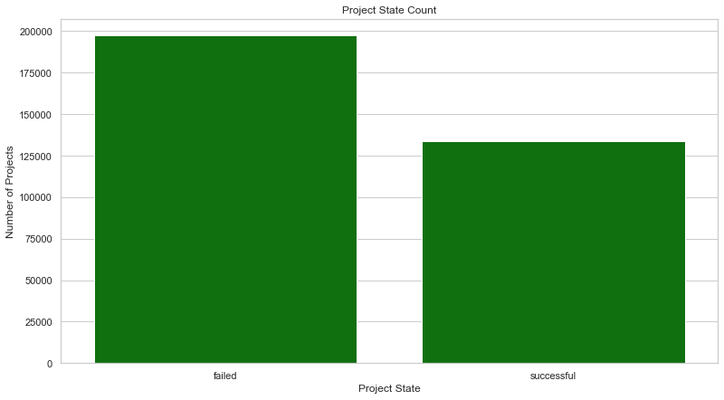

```python
# Success and Failure of projects
plt.figure(figsize=(13,7))
sns.countplot(data_clean['state'],color='g')
plt.title('Project State Count')
plt.xlabel('Project State')
plt.ylabel('Number of Projects')
plt.show()
```

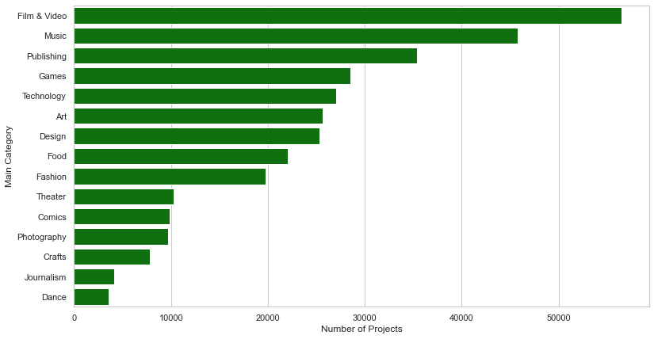

```python
# Total projects per category
plt.figure(figsize=(13,7))
sns.countplot(y=data_clean['main_category'],order=data_clean['main_category'].value_counts().index,color='g')
plt.xlabel('Number of Projects')
plt.ylabel('Main Category')
plt.show()
```

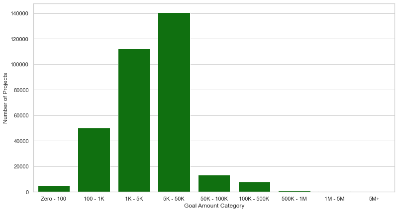

```python
# Goal amount distribution
plt.figure(figsize=(13,7))
sns.countplot(data_clean['project_scale'],color='green')
plt.xlabel('Goal Amount Category')
plt.ylabel('Number of Projects')
plt.show()
```

# 2. Multivariate exploration

In this section, relationship between multiple attributes in the dataset are explored to answer the business questions.

## 2.1 Analysis of Campaigns over time

### Historical Distribution of campaign success and failures

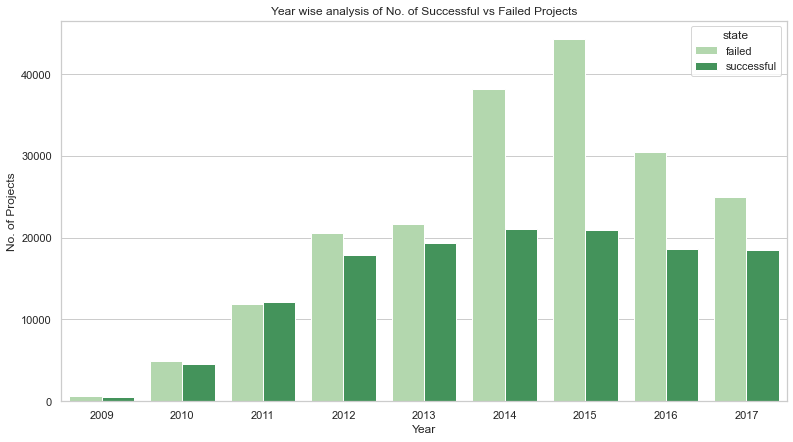

```python
# Which year had the most successful campaign?

df_state = data_clean.groupby(["state","year"]).count().reset_index()
plt.figure(figsize=(13,7))
sns.barplot(x = 'year', y = 'ID', hue = 'state', data = df_state, palette='Greens')
plt.title('Year wise analysis of No. of Successful vs Failed Projects')
plt.xlabel('Year')
plt.ylabel('No. of Projects')
plt.show()
```

2011 was the only year to have had more successful projects than failed projects.

```python
## Calculating success and failure rate
#creating a dataframe grouped by the year, containing sum of successful projects, sum of backers,
year=data_clean.groupby('year')
year_success=year.agg({'success':'sum','ID':'count', 'backers':'sum'}).reset_index()
year_success.head()

# Calculating success rate as % of total projects that were successful
year_success['rate']=year_success['success']/year_success['ID']
year_success.sort_values('rate',ascending=False)
```

|  | year | success | ID | backers | rate |
| --- | --- | --- | --- | --- | --- |
| 2 | 2011 | 12171 | 24046 | 1378505 | 0.506 |
| 0 | 2009 | 579 | 1179 | 42948 | 0.491 |
| 1 | 2010 | 4591 | 9572 | 401558 | 0.480 |
| 4 | 2013 | 19402 | 41086 | 6128522 | 0.472 |
| 3 | 2012 | 17891 | 38477 | 4272773 | 0.465 |
| 8 | 2017 | 18462 | 43419 | 6266077 | 0.425 |
| 7 | 2016 | 18674 | 49094 | 6904298 | 0.380 |
| 5 | 2014 | 21106 | 59304 | 5968349 | 0.356 |
| 6 | 2015 | 20970 | 65271 | 7236703 | 0.321 |

### Calculating Rate of Success through the years

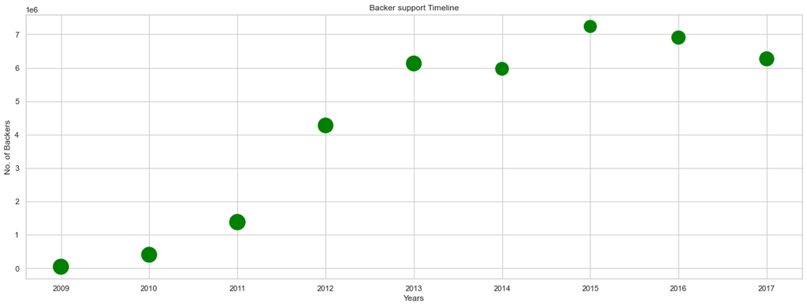

```python
# How has the success rate and support of backers been throughout the years?

plt.figure(figsize=(20,7))
plt.scatter(x=year_success['year'], y=year_success['backers'], s=year_success['rate']*1000, color='g')
plt.title("Backer support Timeline")
plt.xlabel('Years')
plt.ylabel('No. of Backers')
plt.show()
```

### Growth of Goal and Pledged amount through the years

```python
year_amount=data_clean.groupby(['year']).sum()[['usd_pledged_real','usd_goal_real']]
year_amount.reset_index(inplace=True)
#year_amount
```

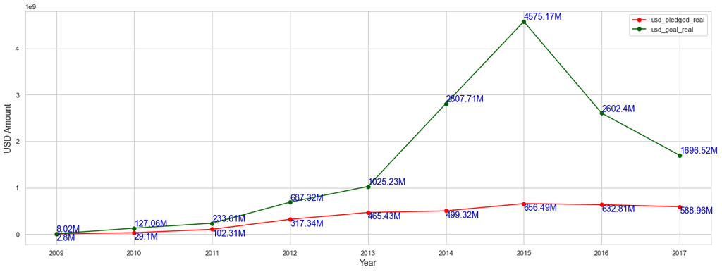

```python
fig,ax = plt.subplots(figsize=(20,7))

#plotting usd_pledged_real graph
ax.plot(year_amount['year'], year_amount["usd_pledged_real"], color="red", marker="o")
# set x-axis label
ax.set_xlabel("Year",fontsize=14)
# set y-axis label
ax.set_ylabel("USD Amount",fontsize=14)

#Annotating usd_pledged_real plot
for i, txt in enumerate(year_amount['usd_pledged_real']):
    plt.annotate(str(round(float(txt/10**6),2))+'M', (year_amount.loc[i,'year'], year_amount.loc[i,'usd_pledged_real']),va='top',size=14,color='#0000BA')

#plotting usd_goal_real graph
ax.plot(year_amount['year'], year_amount["usd_goal_real"],color="darkgreen",marker="o")
plt.xticks(year_amount['year'])
plt.legend(['usd_pledged_real','usd_goal_real'])

#Annotating usd_goal_real plot
for i, txt in enumerate(year_amount['usd_goal_real']):
    plt.annotate(str(round(float(txt/10**6),2))+'M', (year_amount.loc[i,'year'], year_amount.loc[i,'usd_goal_real']),va='bottom',size=14,color='#0000BA')
plt.show()
```

### Understanding the Duration of Projects and Backers distribution

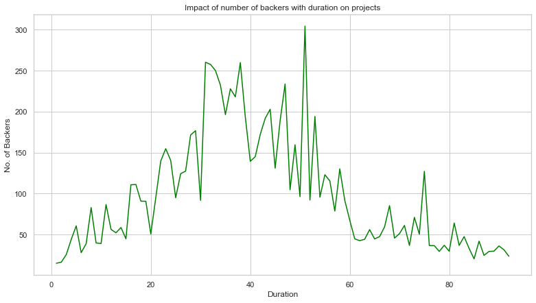

```python
# Does duration impact the number of backers for a project?

plt.figure(figsize=(13,7))
plt.title('Impact of number of backers with duration on projects')
sns.lineplot(data=data_clean, x="duration", y="backers", color = 'green',ci=None)
plt.xlabel('Duration')
plt.ylabel('No. of Backers')
plt.show()
```

## 2.2 Exploration of Main Categories and Categories

### Understanding Successful and Failed Projects in each main category

```python
# filtering out the failed and successful projects for analysis
df_failed = data_clean.query('state == "failed"')
df_success = data_clean.query('state == "successful"')
```

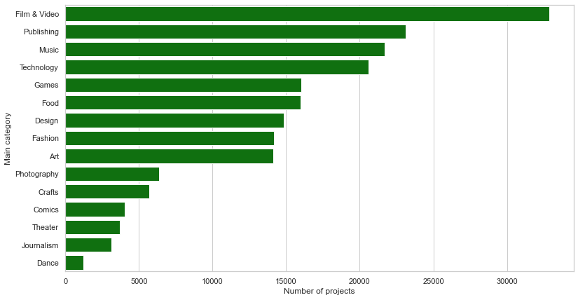

```python
# Which main category has the maximum no. of failed projects in all failed projects combined?
plt.figure(figsize=(13,7))
sns.countplot(y=df_failed['main_category'],order=df_failed['main_category'].value_counts().index ,color = 'green')
plt.xlabel("Number of projects")
plt.ylabel("Main category")
plt.show()
```

Film & Video has the highest number of failed projects followed by Publishing, Music and Technology

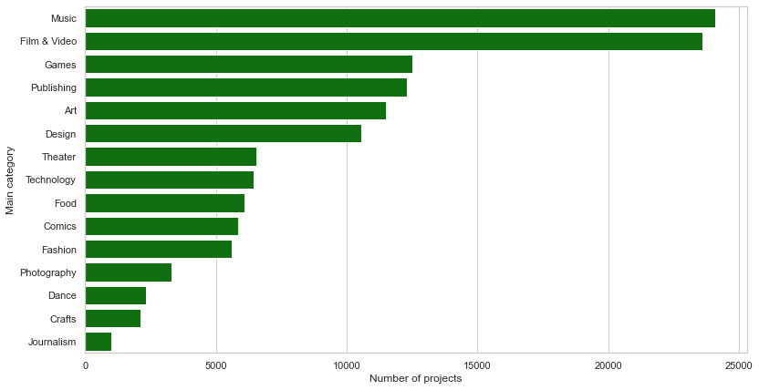

```python
# Which main category has the maximum no. of successful projects in all successful projects combined?
plt.figure(figsize=(13,7))
sns.countplot(y=df_success['main_category'], order=df_success['main_category'].value_counts().index, color='green')
plt.xlabel("Number of projects")
plt.ylabel("Main category")
plt.show()
```

### Duration of campaigns within each main category

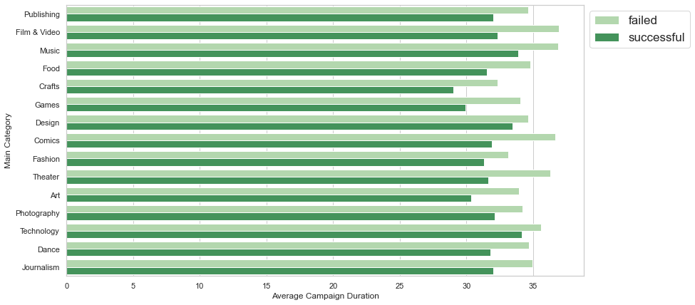

```python
# Average duration
plt.figure(figsize=(13,7))
sns.barplot(data=data_clean,y='main_category',x='duration',palette='Greens', hue='state', ci=None)
plt.xlabel('Average Campaign Duration')
plt.ylabel('Main Category')
# Locate the legend outside of the plot
plt.legend(bbox_to_anchor=(1, 1), loc='upper left', fontsize=17)
plt.show()
```

#### Average Campaign Duration is comparable for all categories. The graph gives us the average duration for successful projects category wise to help individual users estimate their project run time.

### Backer support across Main Categories

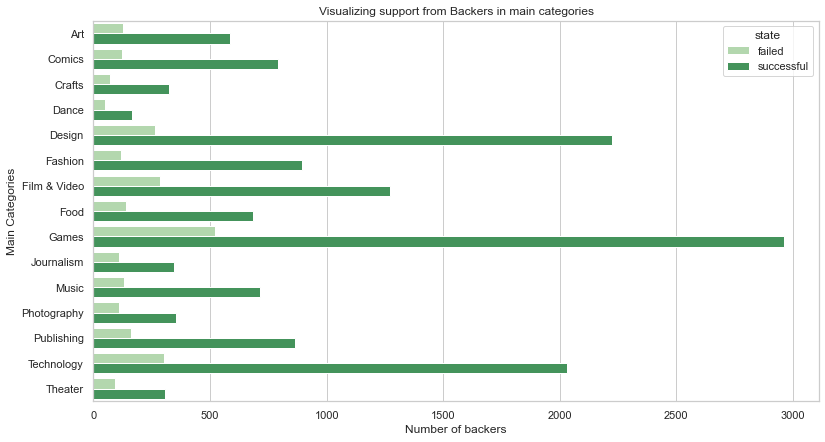

```python
# Which main category got the maximum support?

df_category = data_clean.groupby([data_clean["main_category"], data_clean["state"], data_clean["backers"]]).count().reset_index()
plt.figure(figsize=(13,7))
sns.barplot(y = 'main_category', x = 'backers', hue = 'state', data = df_category, palette='Greens', ci=None)
plt.title('Visualizing support from Backers in main categories')
plt.ylabel('Main Categories')
plt.xlabel('Number of backers')
plt.show()
```

### Success Rate of Main categories

```python
## Calculating success and failure rate
#creating a dataframe grouped by the main category, containing sum of successful projects, sum of backers,
main_category_success=data_clean.groupby('main_category')
main_category_success=main_category_success.agg({'success':'sum','ID':'count', 'backers':'sum'}).reset_index()
main_category_success.head()

# Calculating success rate as % of total projects that were successful
main_category_success['rate']=main_category_success['success']/main_category_success['ID']
#main_category_success.sort_values('rate',ascending=False)
```

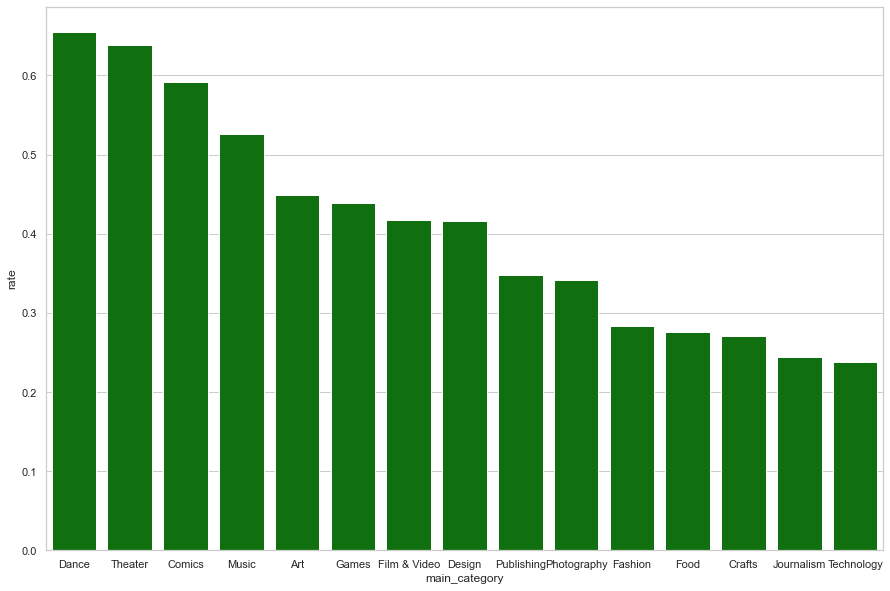

```python
# Success rate barplot of main categories
plt.figure(figsize=(15,10))
order=main_category_success.sort_values('rate',ascending=False)['main_category'].unique()
sns.barplot(data=main_category_success,x='main_category',y='rate',color='green',order=order)
```

### Understanding mean difference between pledged and targeted goal amount across main categories

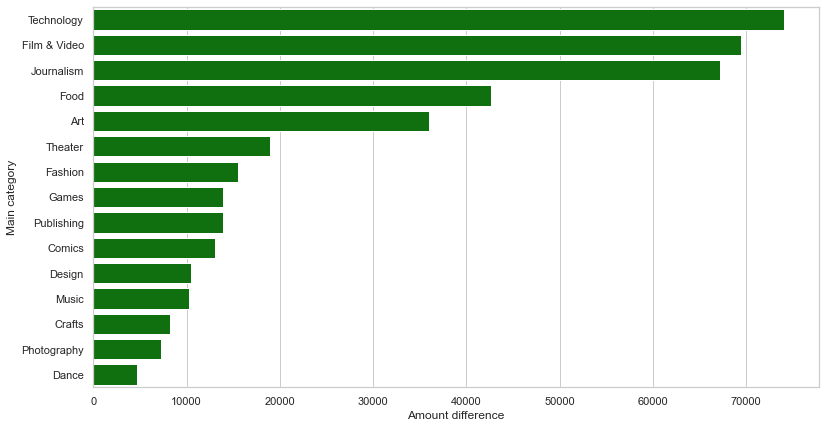

```python
# Which main category has the highest difference in goal and pledged amount?

df_diff=data_clean.groupby(['main_category']).mean().reset_index()
order=df_diff.sort_values("difference",ascending=False)['main_category'].unique()
plt.figure(figsize=(13,7))
sns.barplot(y='main_category', x='difference',order=order, data=df_diff, color='g', ci=None)
plt.xlabel('Amount difference')
plt.ylabel('Main category')
plt.show()
```

```python
# Grouped by main category to get the count of projects and pledged amount summation
main_category_groupby = data_clean.groupby('main_category')
main_category_aggregated = main_category_groupby.agg({'ID':'count', 'usd_pledged_real':'mean'}).reset_index()
```

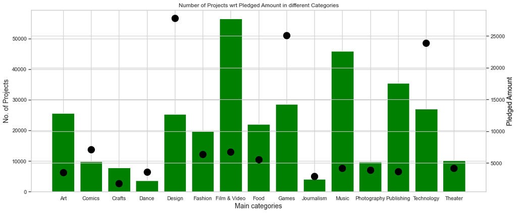

```python
# How has the number of projects been wrt pledged amount in different main categories?

fig,ax = plt.subplots(figsize=(17,7))
# Using a dual-axis graph
ax.bar(main_category_aggregated['main_category'], main_category_aggregated["ID"], color="green")
ax.set_xlabel("Main categories",fontsize=14)
ax.set_ylabel("No. of Projects",fontsize=14)

ax2=ax.twinx()
ax2.scatter(main_category_aggregated['main_category'], main_category_aggregated["usd_pledged_real"],color="black",marker="o", s=200 )
ax2.set_ylabel("Pledged Amount",color="black",fontsize=14)
plt.title('Number of Projects wrt Pledged Amount in different Categories')
plt.show()
```

### Average Pledged Amount per main category for succesful projects

```python
# getting the average of values category wise for successful projects
data_average_clean = data_clean.copy()
data_average_clean = data_average_clean[data_average_clean["success"] == 1]
data_clean_average = data_average_clean.groupby(data_average_clean["main_category"]).mean()
data_clean_average = data_clean_average.reset_index('main_category')
```

```python
#displaying the average of all values category wise
data_clean_average
```

|  | main_category | backers | usd_pledged_real | usd_goal_real | duration | difference | success |
| --- | --- | --- | --- | --- | --- | --- | --- |
| 0 | Art | 90.366 | 6972.620 | 4410.366 | 30.339 | -2562.254 | 1 |
| 1 | Comics | 231.404 | 11385.660 | 5397.352 | 31.909 | -5988.308 | 1 |
| 2 | Crafts | 94.148 | 5629.697 | 3013.431 | 29.027 | -2616.266 | 1 |
| 3 | Dance | 63.396 | 5194.016 | 4601.095 | 31.815 | -592.921 | 1 |
| 4 | Design | 614.892 | 62866.720 | 15408.030 | 33.467 | -47458.690 | 1 |
| 5 | Fashion | 217.001 | 20286.556 | 9080.955 | 31.309 | -11205.600 | 1 |
| 6 | Film & Video | 152.630 | 13956.379 | 11148.072 | 32.309 | -2808.307 | 1 |
| 7 | Food | 180.558 | 17349.391 | 11633.963 | 31.512 | -5715.428 | 1 |
| 8 | Games | 814.384 | 54228.755 | 14857.225 | 29.913 | -39371.530 | 1 |
| 9 | Journalism | 152.306 | 10344.950 | 8148.648 | 32.037 | -2196.302 | 1 |
| 10 | Music | 102.575 | 7348.939 | 5743.301 | 33.886 | -1605.638 | 1 |
| 11 | Photography | 108.746 | 10111.690 | 6490.600 | 32.137 | -3621.091 | 1 |
| 12 | Publishing | 158.823 | 9436.911 | 5897.849 | 32.012 | -3539.062 | 1 |
| 13 | Technology | 717.790 | 92670.795 | 26259.351 | 34.160 | -66411.444 | 1 |
| 14 | Theater | 70.506 | 5973.135 | 5198.044 | 31.616 | -775.091 | 1 |

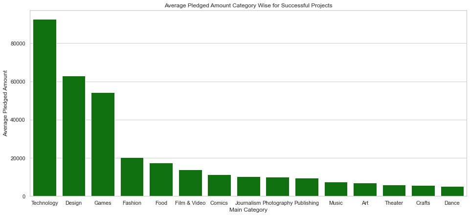

```python
plt.figure(figsize=(16,7))
order=data_clean_average.sort_values("usd_pledged_real",ascending=False)['main_category'].unique()
sns.barplot(data=data_clean_average,y='usd_pledged_real',x='main_category',order=order,color='Green')
plt.title('Average Pledged Amount Category Wise for Successful Projects')
plt.xlabel('Main Category')
plt.ylabel('Average Pledged Amount')
plt.show()
```

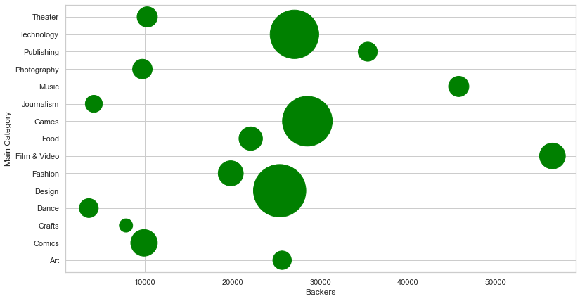

```python
# Average backers
main_category=data_clean.groupby('main_category')
main_category_backers=main_category.agg({'backers':'sum','ID':'count','usd_pledged_real':'sum'}).reset_index()
main_category_backers
# Bubble Plot: Average usd_pledged_real per backer, number of projects and number of backers
plt.figure(figsize=(13,7))
plt.scatter(main_category_backers['ID'],main_category_backers['main_category'],s=main_category_backers['usd_pledged_real']/(main_category_backers['ID']*5),c='g')
plt.xlabel('Backers')
plt.ylabel('Main Category')
plt.show()
```

### Yearly Distribution of campaigns in each main category:

To understand how the number of projects has grown through the year in each main category.

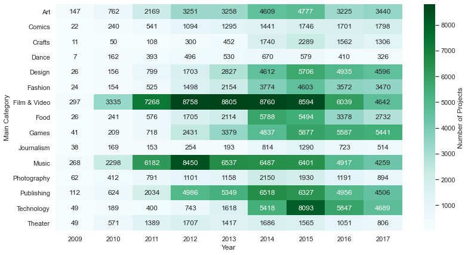

```python
#grouping the data on the basis of year and main category
year_main_cat_groupby=pd.DataFrame(data_clean.groupby(['year','main_category']).count()['ID']).reset_index()

pivot_table_2=year_main_cat_groupby.pivot('main_category','year','ID')

#plotting the pivot table as heatmap
plt.figure(figsize=(13,7))
ax=sns.heatmap(pivot_table_2,cmap='BuGn',annot=True,fmt='.0f')
colorbar1 = ax.collections[0].colorbar
colorbar1.set_label('Number of Projects')
plt.xlabel('Year')
plt.ylabel('Main Category')
plt.show()
```

### Monthly Distribution of campaigns in each main category

To understand which month has the most projects within each main category.

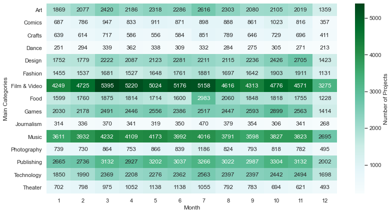

```python
#grouping the data on the basis of year and main category
month_main_cat_groupby=pd.DataFrame(data_clean.groupby(['month','main_category']).count()['ID']).reset_index()

pivot_table_3=month_main_cat_groupby.pivot('main_category','month','ID')

plt.figure(figsize=(13,7))
ax=sns.heatmap(pivot_table_3,cmap='BuGn',annot=True,fmt='.0f')
colorbar1 = ax.collections[0].colorbar
colorbar1.set_label('Number of Projects')
plt.xlabel('Month')
plt.ylabel('Main Categories')
plt.show()
```

## 2.3 Campaign performance across countries

US, Great Britian and Canada have the most number of projects, and also the most number of succesful projects.

```python
## 22 Unique countries
data_clean.country.unique()
```

```
array(['GB', 'US', 'CA', 'AU', 'NO', 'IT', 'DE', 'IE', 'MX', 'ES', 'SE',
       'FR', 'NZ', 'CH', 'AT', 'BE', 'DK', 'HK', 'NL', 'LU', 'SG', 'JP'],
      dtype=object)
```

```python
# Aggregate object for analysis
country=data_clean.groupby('country')
```

### Success and Failure of Projects across Countries

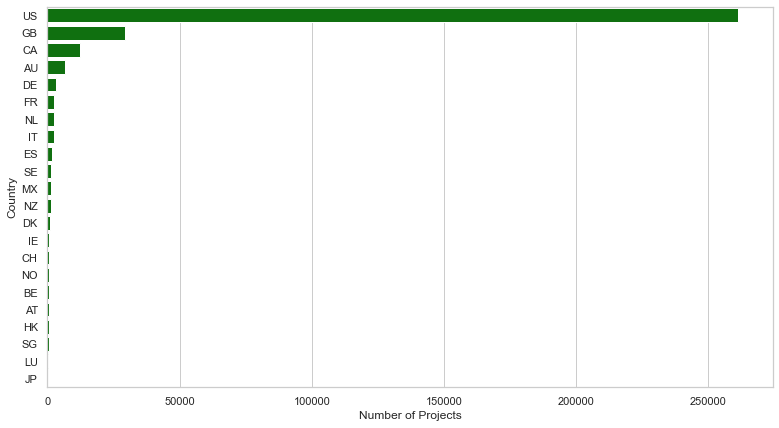

```python
# Total projects
plt.figure(figsize=(13,7))
sns.countplot(y=data_clean['country'],order=data_clean['country'].value_counts().index,color="g")
plt.xlabel('Number of Projects')
plt.ylabel('Country')
plt.show()
```

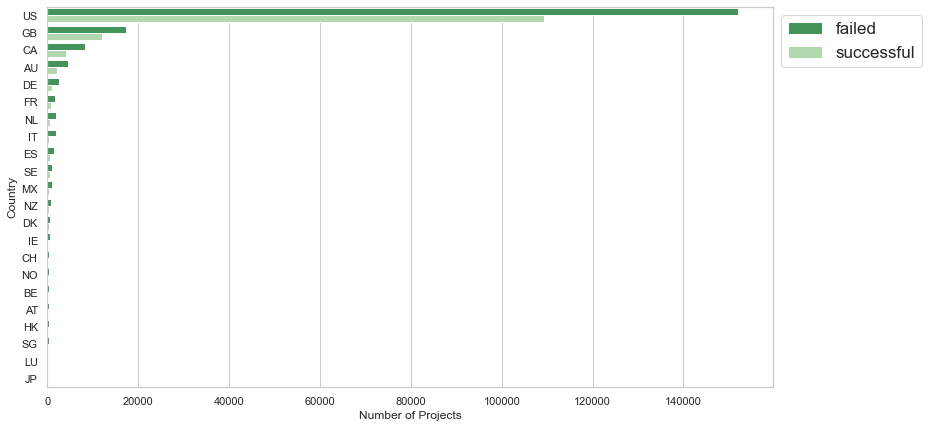

```python
# Breakdown of successful and failed projects
plt.figure(figsize=(13,7))
sns.countplot(y=data_clean['country'],order=data_clean['country'].value_counts().index,palette="Greens_r",hue=data_clean['state'])
plt.xlabel('Number of Projects')
plt.ylabel('Country')
plt.legend(bbox_to_anchor=(1, 1), loc='upper left', fontsize=17)
plt.show()
plt.show()
```

### Goal Amount Distribution in top countries vs least popular countries

To understand what the average goal amount in top countries vs least popular countries.

```python
country=pd.DataFrame(data_clean['country'].value_counts())
country.reset_index(inplace=True)
top_country=country.iloc[:5,:].copy()
bottom_country=country.iloc[-5:,:].copy()
top_country.drop('country',axis=1,inplace=True)
top_country.rename(columns={"index":"country"},inplace=True)
bottom_country.drop('country',axis=1,inplace=True)
bottom_country.rename(columns={"index":"country"},inplace=True)
```

```python
country_goals=data_clean.groupby(['country','project_scale']).agg(projects=('ID','count')).reset_index()
top_country_goals=country_goals.merge(top_country,how='inner',on='country')
bottom_country_goals=country_goals.merge(bottom_country,how='inner',on='country')
```

```python
top_country_goals_pivot=top_country_goals.pivot_table(columns='project_scale',index='country',values='projects')
```

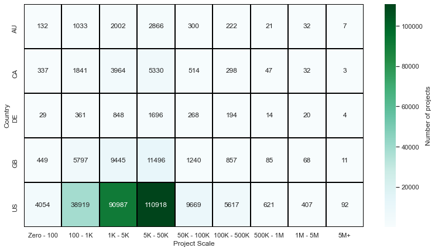

```python
plt.figure(figsize=(13,7))
ax=sns.heatmap(top_country_goals_pivot,linewidths=1,linecolor='black',cmap='BuGn',annot=True,fmt='.0f')
colorbar1 = ax.collections[0].colorbar
colorbar1.set_label('Number of projects')
plt.xlabel('Project Scale')
plt.ylabel('Country')
plt.show()
```

```python
bottom_country_goals_pivot=bottom_country_goals.pivot_table(columns='project_scale',index='country',values='projects')
```

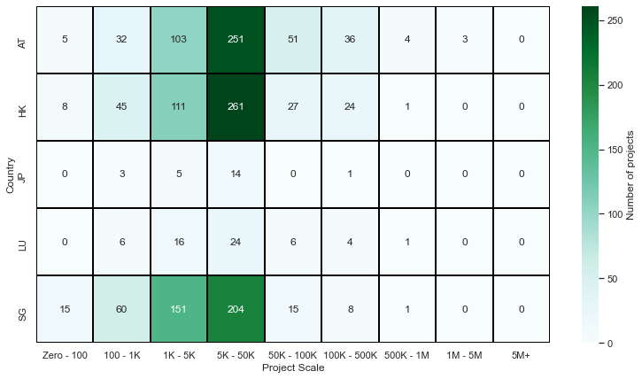

```python
plt.figure(figsize=(13,7))
ax=sns.heatmap(bottom_country_goals_pivot,linewidths=1,linecolor='black',cmap='BuGn',annot=True,fmt='.0f')
colorbar1 = ax.collections[0].colorbar
colorbar1.set_label('Number of projects')
plt.xlabel('Project Scale')
plt.ylabel('Country')
plt.show()
```

The most popular range of target goal amount for Campaigns is $ 5k to $ 50k for both top and bottom most popular countries.